# In-Class Notes: 2012-09-17

## Review from Friday.

1. A model is a representation for a purpose.
2. Statistical models (a) attempt for account for case-to-case variation in a variable (b) are based on data and © put the variation that's accounted for in the context of the variation that remains unexplained.
3. The usual form of a statistical model is response \( = f \)(explanatory).

## A mathematical model of human mood with two parameters.

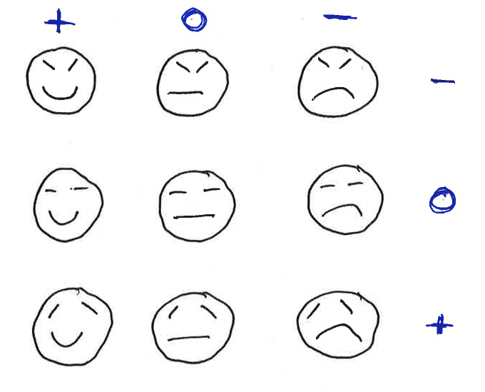

- Which one of these is the best representation of your mood today?
- Which word would you use to label each graph?

I call my model a mathematical model since it is governed by two mathematical quantities: the curvature of the mouth and the slope of the (left) eyebrow.

The word is also a model. That we can communicate without the word is evidence that the cartoon face really is representing something.

More skilled modelers can add more details — more parameters, more levels to the parameters — to get a better representation.

## Constructing some models

[A handout for students](https://dl.dropbox.com/u/5098197/ISM/Unfit-Models.pdf)

We're going to build some groupwise models. Later on, we're going to **fit** models, that is, let the data dictate the model parameters in some *optimal* way.

We'll be using some new software, so make sure to load it:

```r
fetchData("m155development.R")
```

Construct each of these models but make up **your own parameters**, don't just use the ones here. (Of course, you won't have a solid idea of what the parameters should be. Just use your best judgment.) Test out your function by giving it, in quotes,  
the level as an input.

- A model of height versus sex. Levels for sex: M and F.

```r
height = listFun(F = 63, M = 68)
height("F")  # testing it for females
```

```
##  F
## 63
```

- Age at marriage as s function of race. Levels of Race: Black, Hispanic, White

```r
age = listFun(Black = 25, White = 28, Hispanic = 22)
age("Hispanic")
```

```
## Hispanic
##       22
```

- Monthly cost of buying $10-50K of life insurance from the AARP versus sex. Level for sex: F and M

```r
cost = listFun(F = 20, M = 24)
cost("M")
```

```
##  M
## 24
```

- Probability of dying in the next 30 years versus smoking status. Levels for smoker: Yes and No

```r
dead = listFun(Yes = 0.8, No = 0.4)
dead("Yes")
```

```
## Yes
## 0.8
```

INSTRUCTIONS TO STUDENTS: Make your own model for each of these. Then we're going to have a competition.

## Evaluating your model against data

We happen to have some data that reflects each of these situations. The data sets are:

```r
g = fetchData("Galton")
```

```
## Data Galton found in package.
```

```r
m = fetchData("marriage.csv")
```

```
## Retrieving from http://www.mosaic-web.org/go/datasets/marriage.csv
```

```r
i = fetchData("AARP-insurance.csv")
```

```
## Retrieving from http://www.mosaic-web.org/go/datasets/AARP-insurance.csv
```

```r
w = fetchData("whickham.csv")
```

```
## Retrieving from http://www.mosaic-web.org/go/datasets/whickham.csv
```